# Assignment 2: Spatial Analysis and Visualization

Healthcare Access and Equity in Pennsylvania

Author

Jinheng

Published

October 7, 2025

## Assignment Overview

**Learning Objectives:**

- Apply spatial operations to answer policy-relevant research questions
- Integrate census demographic data with spatial analysis
- Create publication-quality visualizations and maps
- Work with spatial data from multiple sources
- Communicate findings effectively for policy audiences

## Part 1: Healthcare Access for Vulnerable Populations

### Research Question

**Which Pennsylvania counties have the highest proportion of vulnerable populations (elderly + low-income) living far from hospitals?**

Your analysis should identify counties that should be priorities for healthcare investment and policy intervention.

### Required Analysis Steps

Complete the following analysis, documenting each step with code and brief explanations:

#### Step 1: Data Collection (5 points)

Load the required spatial data:

- Pennsylvania county boundaries
- Pennsylvania hospitals (from lecture data)
- Pennsylvania census tracts

**Your Task:**

```r
# Load required packages
library(sf)
library(tidyverse)
library(tigris)
library(tidycensus)
library(scales)
library(patchwork)
library(here)
library(knitr)

# Add this near the top of your .qmd after loading libraries
options(tigris_use_cache = TRUE)
options(tigris_progress = FALSE)  # Suppress tigris progress bars

# Load spatial data
pa_counties <- st_read("data/Pennsylvania_County_Boundaries.shp")
hospitals <- st_read("data/hospitals.geojson")
census_tracts <- tracts(state = "PA", cb = TRUE)

hospitals <- st_transform(hospitals, st_crs(pa_counties))
census_tracts <- st_transform(census_tracts, st_crs(pa_counties))

# Check that all data loaded correctly
```

**Questions to answer:**

- How many hospitals are in your dataset? 223
- How many census tracts? 3445
- What coordinate reference system is each dataset in? I converted them all in WGS 84 / Pseudo-Mercator

#### Step 2: Get Demographic Data

Use `tidycensus` to download tract-level demographic data for Pennsylvania.

**Required variables:**

- Total population
- Median household income
- Population 65 years and over (you may need to sum multiple age categories)

**Your Task:**

```r
# Get demographic data from ACS
tract_data <- get_acs(
  geography = "tract",
  state     = "42",
  variables = c(
    total_population = "B01003_001",
    median_household_income = "B19013_001"
  ),
  year = 2023,
  survey = "acs5",
  output = "wide",
  progress = FALSE
)

age_data <- get_acs(
  geography = "tract",
  state     = "42",
  variables = c(
    male_65 <- c("B01001_020","B01001_021","B01001_022","B01001_023","B01001_024","B01001_025"),
    female_65 <- c("B01001_044","B01001_045","B01001_046","B01001_047","B01001_048","B01001_049")
  ),
  year = 2023,
  survey = "acs5",
  progress = FALSE
) %>%
  group_by (GEOID) %>%
  summarise(pop_65 = sum(estimate, na.rm = TRUE))


tract_data <- tract_data %>%
  left_join(age_data, by = "GEOID")


tract_data %>%
  summarise(missing_data = sum(is.na(median_household_incomeE)))
```

```
# A tibble: 1 × 1
  missing_data
         <int>
1           66
```

```r
tract_data %>%
  summarise(median_income = sum(median(median_household_incomeE, na.rm = TRUE)))
```

```
# A tibble: 1 × 1
  median_income
          <dbl>
1        72944.
```

```r
# Join to tract boundaries

census_tracts_joined <- census_tracts %>%
  left_join(tract_data, by = "GEOID")
```

**Questions to answer:**

- What year of ACS data are you using? 2023
- How many tracts have missing income data? 66
- What is the median income across all PA census tracts? 72943.5

#### Step 3: Define Vulnerable Populations

Identify census tracts with vulnerable populations based on TWO criteria: 1. Low median household income (choose an appropriate threshold) 2. Significant elderly population (choose an appropriate threshold)

**Your Task:**

```r
# Filter for vulnerable tracts based on your criteria

census_tracts_joined <- census_tracts_joined %>%
  mutate(
    percentage_65 = pop_65/total_populationE
  )

vulnerable_tracts <- census_tracts_joined %>%
  filter(median_household_incomeE < 48000,
         percentage_65 > 0.20
         )
```

**Questions to answer:**

- What income threshold did you choose and why? For the income threshold, I chose 48,000 based on the 2025 poverty guidelines by the USCIS. For a family with four people, 150% of the federal poverty level is $48,225.
- What elderly population threshold did you choose and why? For the age threshold, I chose the percentage of people over 65 years old is over 20%, which can be seen as an elderly community.
- How many tracts meet your vulnerability criteria? 126
- What percentage of PA census tracts are considered vulnerable by your definition? the percentage of vulnerable tracts = 126 / 3445 = 3.66%

#### Step 4: Calculate Distance to Hospitals

For each vulnerable tract, calculate the distance to the nearest hospital.

**Your Task:**

```r
# Transform to appropriate projected CRS

vulnerable_tracts_proj <- vulnerable_tracts %>%
  st_transform(5070) # 5070 is for the whole country. For south PA alone, we can use 3365, which is more precise.

hospitals_proj <- hospitals %>%
  st_transform(5070)


# Calculate distance from each tract centroid to nearest hospital

tract_centroids <- st_centroid(vulnerable_tracts_proj)

nearest_hospital_idx <- st_nearest_feature(tract_centroids, hospitals_proj)

dist_to_hospital <- st_distance(
  tract_centroids,
  hospitals_proj[nearest_hospital_idx, ],
  by_element = TRUE
)


vulnerable_tracts_proj <- vulnerable_tracts_proj %>%
  mutate(
    dist_to_hospital = as.numeric(dist_to_hospital),
    dist_to_hospital_mi = dist_to_hospital * 0.000621371
  )

distant_data <- vulnerable_tracts_proj %>%
  summarise(
    avg_distance = mean(dist_to_hospital_mi, na.rm = TRUE),
    max_dist = max(dist_to_hospital_mi, na.rm = TRUE),
  )


num_over15 <- vulnerable_tracts_proj %>%
  filter(dist_to_hospital_mi > 15) %>%
  summarise(
    n_over15 = n(),
  )
```

**Requirements:**

- Use an appropriate projected coordinate system for Pennsylvania
- Calculate distances in miles
- Explain why you chose your projection

**Questions to answer:**

- What is the average distance to the nearest hospital for vulnerable tracts? 2.8 miles
- What is the maximum distance? 18.6 miles
- How many vulnerable tracts are more than 15 miles from the nearest hospital? 1

#### Step 5: Identify Underserved Areas

Define “underserved” as vulnerable tracts that are more than 15 miles from the nearest hospital.

**Your Task:**

```r
# Create underserved variable

undeserved <- vulnerable_tracts_proj %>%
  filter(dist_to_hospital_mi > 15)
```

**Questions to answer:**

- How many tracts are underserved? only 1!
- What percentage of vulnerable tracts are underserved? 1/126 = 0.79%
- Does this surprise you? Why or why not? No, I looked at the distance data of the vulnerable tracts, most of them (92.9%) are under 10 miles (16000m). I think 15 miles is a very big number, so we just have one tract fulfill all the requirements.

#### Step 6: Aggregate to County Level

Use spatial joins and aggregation to calculate county-level statistics about vulnerable populations and hospital access.

**Your Task:**

```r
# Spatial join tracts to counties
vulnerable_tracts_proj <- st_transform(vulnerable_tracts_proj, st_crs(pa_counties))
undeserved  <- st_transform(undeserved , st_crs(pa_counties))

counties_num = census_tracts %>%
  st_centroid() %>%
  st_join(pa_counties%>% select(COUNTY_NAM)) %>%
  st_drop_geometry() %>%
  group_by(COUNTY_NAM) %>%
  summarize(
    n_tract =  n(),
  )%>%
  arrange(n_tract)

counties_vuln <- vulnerable_tracts_proj %>%
  st_centroid() %>%
  st_join(pa_counties%>% select(COUNTY_NAM)) %>%
  st_drop_geometry() %>%
  group_by(COUNTY_NAM) %>%
  summarize(
    n_vuln =  n(),
    avg_dist_vuln_mi = mean(dist_to_hospital_mi, na.rm = TRUE),
    total_vuln_pop = sum(pop_65, na.rm = TRUE)
  ) %>%
  arrange(desc(total_vuln_pop))

counties_unders <- undeserved %>%
  st_centroid() %>%
  st_join(pa_counties%>% select(COUNTY_NAM)) %>%
  st_drop_geometry() %>%
  group_by(COUNTY_NAM) %>%
  summarize(
    n_unders =  n(),
  ) %>%
  arrange(desc(n_unders))



# Aggregate statistics by county

counties_stat = counties_num %>%
  left_join(counties_vuln, by = "COUNTY_NAM") %>%
  left_join(counties_unders, by = "COUNTY_NAM") %>%
  mutate(
    percentage_unders = n_unders / n_vuln,
    percentage_vuln = n_vuln / n_tract
  )%>%
  arrange(desc(percentage_vuln))
```

**Required county-level statistics:**

- Number of vulnerable tracts
- Number of underserved tracts
- Percentage of vulnerable tracts that are underserved
- Average distance to nearest hospital for vulnerable tracts
- Total vulnerable population

**Questions to answer:**

#### Step 7: Create Summary Table

Create a professional table showing the top 10 priority counties for healthcare investment.

**Your Task:**

```r
# Create and format priority counties table
# metrics for the priority: vulnerable index = normalized_number_of_vulnerable_tracts*0.3 + normalized_average_distant _hospital*0.5 + normalized_total_population*0.2

scale_minmax <- function(x) {
  rng <- range(x, na.rm = TRUE)
  if (!is.finite(diff(rng)) || diff(rng) == 0) return(rep(0.5, length(x)))
  (x - rng[1]) / diff(rng)
}

counties_stat_index <- counties_stat %>%
  mutate(
    n_vuln_norm = scale_minmax(n_vuln),
    avg_dist_vuln_mi_norm = scale_minmax(avg_dist_vuln_mi),
    total_vuln_pop_norm = scale_minmax(total_vuln_pop),
    percentage_vuln_norm = scale_minmax(percentage_vuln)
  ) %>%
   mutate(
     vuln_index =
       0.3  * n_vuln_norm +
       0.5 * avg_dist_vuln_mi_norm +
       0.2 * total_vuln_pop_norm
   ) %>%
  arrange(desc(vuln_index))


#make table

counties_table <- counties_stat_index %>%
  select(
    county_name = COUNTY_NAM,
    vulnerable_index = vuln_index,
    vulnerable_tract_number = n_vuln,
    average_dist_to_hospital = avg_dist_vuln_mi,
    total_vulnerable_pop = total_vuln_pop
  ) %>%
  mutate(
    vulnerable_index = round(vulnerable_index, 3),
    average_dist_to_hospital = round(average_dist_to_hospital, 2),
    total_vulnerable_pop = comma(total_vulnerable_pop)
  )%>%
  arrange(desc(vulnerable_index))

kable(
  counties_table,
  caption = "PA County-level Vulnerability Summary",
  align = "lcccc"
)
```

PA County-level Vulnerability Summary

| county_name | vulnerable_index | vulnerable_tract_number | average_dist_to_hospital | total_vulnerable_pop |
| --- | --- | --- | --- | --- |
| ALLEGHENY | 0.519 | 28 | 2.39 | 15,213 |
| CAMERON | 0.502 | 1 | 18.56 | 504 |
| PHILADELPHIA | 0.409 | 19 | 0.89 | 18,022 |
| HUNTINGDON | 0.383 | 1 | 14.18 | 730 |
| NORTHUMBERLAND | 0.321 | 3 | 10.81 | 1,603 |
| CAMBRIA | 0.226 | 8 | 4.15 | 4,588 |
| VENANGO | 0.218 | 1 | 8.40 | 363 |
| FAYETTE | 0.183 | 7 | 2.55 | 5,780 |
| ERIE | 0.179 | 7 | 2.35 | 5,923 |
| WARREN | 0.178 | 2 | 6.19 | 1,257 |
| LANCASTER | 0.175 | 1 | 6.60 | 1,034 |
| LUZERNE | 0.153 | 6 | 2.51 | 4,195 |
| WESTMORELAND | 0.150 | 6 | 2.86 | 3,057 |
| LAWRENCE | 0.149 | 3 | 4.52 | 1,793 |
| NORTHAMPTON | 0.130 | 1 | 5.03 | 850 |
| CLINTON | 0.127 | 1 | 4.89 | 913 |
| DELAWARE | 0.120 | 6 | 1.32 | 4,179 |
| LACKAWANNA | 0.104 | 5 | 1.67 | 2,871 |
| LEHIGH | 0.092 | 1 | 3.42 | 1,417 |
| BEAVER | 0.076 | 2 | 2.53 | 1,291 |
| BLAIR | 0.076 | 2 | 2.18 | 2,079 |
| INDIANA | 0.070 | 1 | 2.63 | 1,447 |
| WASHINGTON | 0.068 | 2 | 2.39 | 915 |
| LYCOMING | 0.066 | 1 | 2.90 | 470 |
| MERCER | 0.063 | 3 | 1.42 | 1,866 |
| JEFFERSON | 0.057 | 2 | 1.72 | 1,566 |
| MIFFLIN | 0.038 | 1 | 1.87 | 516 |
| YORK | 0.028 | 1 | 1.55 | 425 |
| CRAWFORD | 0.015 | 1 | 0.93 | 787 |
| WAYNE | 0.014 | 1 | 0.83 | 951 |
| SOMERSET | 0.008 | 1 | 0.82 | 399 |
| BUTLER | 0.000 | 1 | 0.56 | 400 |
| NA | NA | NA | NA | NA |
| FOREST | NA | NA | NA | NA |
| FULTON | NA | NA | NA | NA |
| MONTOUR | NA | NA | NA | NA |
| SULLIVAN | NA | NA | NA | NA |
| JUNIATA | NA | NA | NA | NA |
| POTTER | NA | NA | NA | NA |
| WYOMING | NA | NA | NA | NA |
| SNYDER | NA | NA | NA | NA |
| ELK | NA | NA | NA | NA |
| GREENE | NA | NA | NA | NA |
| PERRY | NA | NA | NA | NA |
| TIOGA | NA | NA | NA | NA |
| UNION | NA | NA | NA | NA |
| BEDFORD | NA | NA | NA | NA |
| MCKEAN | NA | NA | NA | NA |
| SUSQUEHANNA | NA | NA | NA | NA |
| CLARION | NA | NA | NA | NA |
| BRADFORD | NA | NA | NA | NA |
| COLUMBIA | NA | NA | NA | NA |
| CARBON | NA | NA | NA | NA |
| ARMSTRONG | NA | NA | NA | NA |
| CLEARFIELD | NA | NA | NA | NA |
| PIKE | NA | NA | NA | NA |
| ADAMS | NA | NA | NA | NA |
| FRANKLIN | NA | NA | NA | NA |
| LEBANON | NA | NA | NA | NA |
| CENTRE | NA | NA | NA | NA |
| SCHUYLKILL | NA | NA | NA | NA |
| MONROE | NA | NA | NA | NA |
| CUMBERLAND | NA | NA | NA | NA |
| DAUPHIN | NA | NA | NA | NA |
| BERKS | NA | NA | NA | NA |
| CHESTER | NA | NA | NA | NA |
| BUCKS | NA | NA | NA | NA |
| MONTGOMERY | NA | NA | NA | NA |

**Requirements:**

- Use `knitr::kable()` or similar for formatting
- Include descriptive column names
- Format numbers appropriately (commas for population, percentages, etc.)
- Add an informative caption
- Sort by priority (you decide the metric)

## Part 2: Comprehensive Visualization

Using the skills from Week 3 (Data Visualization), create publication-quality maps and charts.

### Map 1: County-Level Choropleth

Create a choropleth map showing healthcare access challenges at the county level.

**Your Task:**

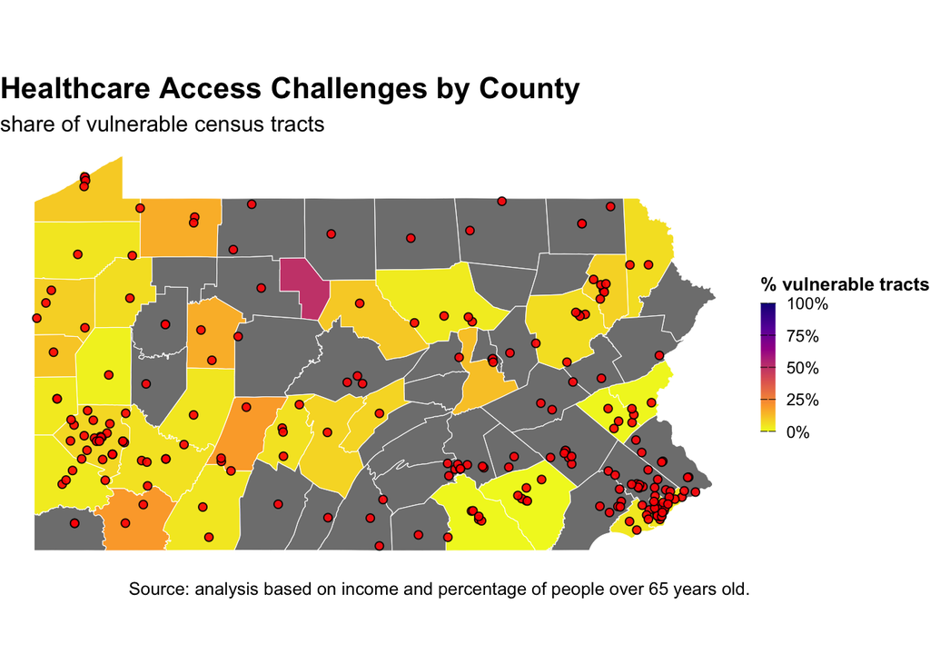

```r
# Create county-level access map
# I use percentage of vulnerable tract here

library(ggplot2)

counties_stat_sf <- pa_counties %>%
  select(COUNTY_NAM, geometry) %>%
  left_join(counties_stat, by = "COUNTY_NAM")

p1 <- ggplot() +
  # county base map
  geom_sf(
    data = counties_stat_sf,
    aes(fill = percentage_vuln),
    color = "white", size = 0.2
  ) +
  # hospitals
  geom_sf(
    data = hospitals_proj,
    shape = 21, fill = "red",
    size = 1.8, alpha = 0.9
  ) +
  # legend
  scale_fill_viridis_c(
    name = "% vulnerable tracts",
    labels = label_percent(accuracy = 1),
    limits = c(0, 1),
    option = "C",
    direction = -1
  ) +
  coord_sf() +
  theme_void(base_size = 12) +
  theme(
    legend.position = "right",
    legend.title = element_text(size = 10, face = "bold"),
    legend.text  = element_text(size = 9),
    plot.title   = element_text(face = "bold", size = 16),
    plot.subtitle= element_text(size = 12)
  ) +
  labs(
    title    = "Healthcare Access Challenges by County",
    subtitle = "share of vulnerable census tracts",
    caption  = "Source: analysis based on income and percentage of people over 65 years old."
  ) +
  guides(fill = guide_colorbar(
    barheight = unit(70, "pt"),
    barwidth  = unit(8,  "pt"),
    ticks.colour = "black"
  ))

p1
```

**Requirements:**

- Fill counties by percentage of vulnerable tracts that are underserved
- Include hospital locations as points
- Use an appropriate color scheme
- Include clear title, subtitle, and caption
- Use `theme_void()` or similar clean theme
- Add a legend with formatted labels

### Map 2: Detailed Vulnerability Map

Create a map highlighting underserved vulnerable tracts.

**Your Task:**

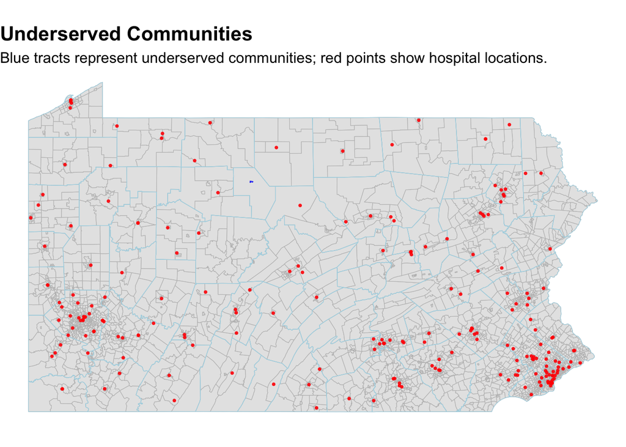

```r
# Create detailed tract-level map

p2 <- ggplot() +
  # tract base map
  geom_sf(
    data = census_tracts,
    color = "grey", size = 0.1
  ) +
  # county base map
  geom_sf(
    data = pa_counties,
    color = "lightblue", size = 0.5,fill = NA,
  ) +
  # hospitals
  geom_sf(
    data = hospitals_proj,
    shape = 16, color = "red",
    size = 1, alpha = 0.9
  ) +
  # underserved community
  geom_sf(
    data = undeserved,
    color = "blue"
  )+
  coord_sf() +
  theme_void(base_size = 12) +
  theme(
    plot.title   = element_text(face = "bold", size = 16),
    plot.subtitle= element_text(size = 12)
  ) +
  labs(
    title    = "Underserved Communities",
    subtitle = "Blue tracts represent underserved communities; red points show hospital locations."
  ) +
  guides(fill = guide_colorbar(
    barheight = unit(70, "pt"),
    barwidth  = unit(8,  "pt"),
    ticks.colour = "black"
  ))

p2
```

```r
#only one very small blue tract in the center of the map
```

**Requirements:**

- Show underserved vulnerable tracts in a contrasting color
- Include county boundaries for context
- Show hospital locations
- Use appropriate visual hierarchy (what should stand out?)
- Include informative title and subtitle

### Chart: Distribution Analysis

Create a visualization showing the distribution of distances to hospitals for vulnerable populations.

**Your Task:**

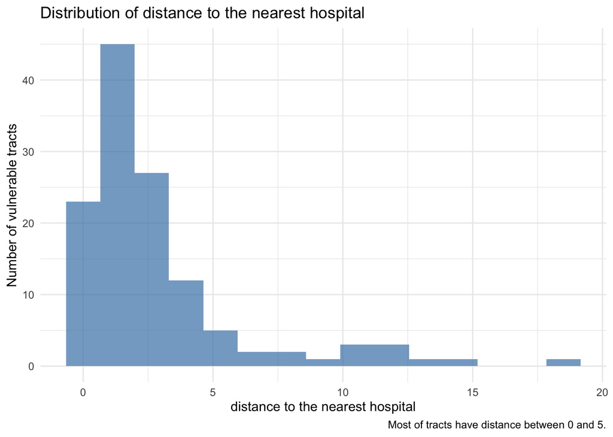

```r
# Create distribution visualization

# Histogram or density plot of distances
ggplot(vulnerable_tracts_proj) +
  aes(x = dist_to_hospital_mi) +
  geom_histogram(bins = 15, fill = "steelblue", alpha = 0.7) +
  labs(
    title = "Distribution of distance to the nearest hospital",
    x = "distance to the nearest hospital",
    y = "Number of vulnerable tracts",
    caption  = "Most of tracts have distance between 0 and 5."
  ) +
  theme_minimal()
```

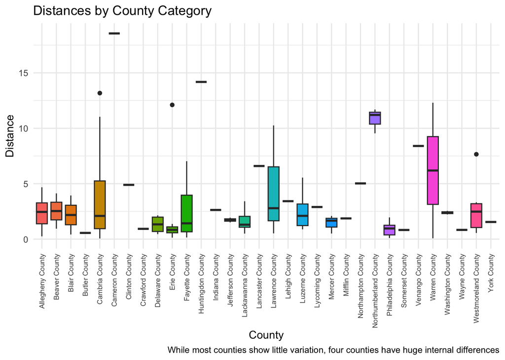

```r
# Box plot comparing distances across regions
ggplot(vulnerable_tracts_proj) +
  aes(x = NAMELSADCO, y = dist_to_hospital_mi, fill = NAMELSADCO) +
  geom_boxplot() +
  labs(
    title = "Distances by County Category",
    x = "County",
    y = "Distance",
    caption  = "While most counties show little variation, four counties have huge internal differences"
  ) +
  theme_minimal() +
  theme(legend.position = "none")+
  theme(
  axis.text.x = element_text(angle = 90, vjust = 0.5, hjust = 1, size = 7)
)
```

[figure not shown]

```r
# Bar chart of underserved tracts by county
#only 1 underserved tracts in my study, it is Census Tract 9601 in the Cameron County


# Scatter plot of distance vs. vulnerable population size
ggplot(vulnerable_tracts_proj) +
  aes(x = dist_to_hospital_mi, y = total_populationE) +
  geom_point(color = "steelblue", alpha = 0.6, size = 2) +
  geom_smooth(
    method = "lm",
    se = TRUE,
    color = "darkred",
    fill = "pink",
    linewidth = 1
  ) +
  labs(
    title = "distance vs. vulnerable population size",
    x = "Distance to the nearest hospital",
    y = "Vulnerable population size",
    caption  = str_wrap("More vulnerable population, little distance to hospital. Since hospitals are designed to located near population clusters, and we didn't limit this effect in this study ", width = 90)
  ) +
  theme_minimal() +
  scale_x_continuous() +
  scale_y_continuous(labels = comma)
```

**Suggested chart types:**

- Histogram or density plot of distances
- Box plot comparing distances across regions
- Bar chart of underserved tracts by county
- Scatter plot of distance vs. vulnerable population size

**Requirements:**

- Clear axes labels with units
- Appropriate title
- Professional formatting
- Brief interpretation (1-2 sentences as a caption or in text)

## Part 3: Bring Your Own Data Analysis

Choose your own additional spatial dataset and conduct a supplementary analysis.

### Challenge Options

Choose ONE of the following challenge exercises, or propose your own research question using OpenDataPhilly data (https://opendataphilly.org/datasets/).

**Note these are just loose suggestions to spark ideas - follow or make your own as the data permits and as your ideas evolve. This analysis should include bringing in your own dataset, ensuring the projection/CRS of your layers align and are appropriate for the analysis (not lat/long or geodetic coordinate systems). The analysis portion should include some combination of spatial and attribute operations to answer a relatively straightforward question**

#### Education & Youth Services

**Option A: Educational Desert Analysis**

- **Data:** Schools, Libraries, Recreation Centers, Census tracts (child population)
- **Question:** “Which neighborhoods lack adequate educational infrastructure for children?”
- **Operations:** Buffer schools/libraries (0.5 mile walking distance), identify coverage gaps, overlay with child population density
- **Policy relevance:** School district planning, library placement, after-school program siting

**Option B: School Safety Zones** - **Data:** Schools, Crime Incidents, Bike Network - **Question:** “Are school zones safe for walking/biking, or are they crime hotspots?” - **Operations:** Buffer schools (1000ft safety zone), spatial join with crime incidents, assess bike infrastructure coverage - **Policy relevance:** Safe Routes to School programs, crossing guard placement

#### Environmental Justice

**Option C: Green Space Equity**

- **Data:** Parks, Street Trees, Census tracts (race/income demographics)
- **Question:** “Do low-income and minority neighborhoods have equitable access to green space?”
- **Operations:** Buffer parks (10-minute walk = 0.5 mile), calculate tree canopy or park acreage per capita, compare by demographics

## **Policy relevance:** Climate resilience, environmental justice, urban forestry investment

#### Public Safety & Justice

**Option D: Crime & Community Resources**

- **Data:** Crime Incidents, Recreation Centers, Libraries, Street Lights
- **Question:** “Are high-crime areas underserved by community resources?”
- **Operations:** Aggregate crime counts to census tracts or neighborhoods, count community resources per area, spatial correlation analysis

## **Policy relevance:** Community investment, violence prevention strategies

#### Infrastructure & Services

**Option E: Polling Place Accessibility**

- **Data:** Polling Places, SEPTA stops, Census tracts (elderly population, disability rates)
- **Question:** “Are polling places accessible for elderly and disabled voters?”
- **Operations:** Buffer polling places and transit stops, identify vulnerable populations, find areas lacking access
- **Policy relevance:** Voting rights, election infrastructure, ADA compliance

#### Health & Wellness

**Option F: Recreation & Population Health**

- **Data:** Recreation Centers, Playgrounds, Parks, Census tracts (demographics)
- **Question:** “Is lack of recreation access associated with vulnerable populations?”
- **Operations:** Calculate recreation facilities per capita by neighborhood, buffer facilities for walking access, overlay with demographic indicators
- **Policy relevance:** Public health investment, recreation programming, obesity prevention

#### Emergency Services

**Option G: EMS Response Coverage**

- **Data:** Fire Stations, EMS stations, Population density, High-rise buildings
- **Question:** “Are population-dense areas adequately covered by emergency services?”
- **Operations:** Create service area buffers (5-minute drive = ~2 miles), assess population coverage, identify gaps in high-density areas
- **Policy relevance:** Emergency preparedness, station siting decisions

#### Arts & Culture

**Option H: Cultural Asset Distribution**

- **Data:** Public Art, Museums, Historic sites/markers, Neighborhoods
- **Question:** “Do all neighborhoods have equitable access to cultural amenities?”
- **Operations:** Count cultural assets per neighborhood, normalize by population, compare distribution across demographic groups
- **Policy relevance:** Cultural equity, tourism, quality of life, neighborhood identity

### Data Sources

**OpenDataPhilly:** https://opendataphilly.org/datasets/

- Most datasets available as GeoJSON, Shapefile, or CSV with coordinates
- Always check the Metadata for a data dictionary of the fields.

**Additional Sources:**

- **Pennsylvania Open Data:** https://data.pa.gov/
- **Census Bureau (via tidycensus):** Demographics, economic indicators, commute patterns
- **TIGER/Line (via tigris):** Geographic boundaries

### Recommended Starting Points

**If you’re feeling confident:** Choose an advanced challenge with multiple data layers. **If you are a beginner, choose something more manageable that helps you understand the basics**

**If you have a different idea:** Propose your own question! Just make sure:

- You can access the spatial data
- You can perform at least 2 spatial operations

### Your Analysis

**Your Task:**

1. **Find and load additional data**
   - Document your data source
   - Check and standardize the CRS
   - Provide basic summary statistics

```r
# Load your additional dataset

library(sf)

schools <- st_read("Data/Schools/Schools.shp")
crime <- st_read("Data/Crime/Crime.shp")
```

```
replacing null geometries with empty geometries
Simple feature collection with 160388 features and 13 fields (with 6744 geometries empty)
Geometry type: POINT
Dimension:     XY
Bounding box:  xmin: -80.50237 ymin: 39.87688 xmax: -74.95784 ymax: 42.22434
Geodetic CRS:  WGS 84
```

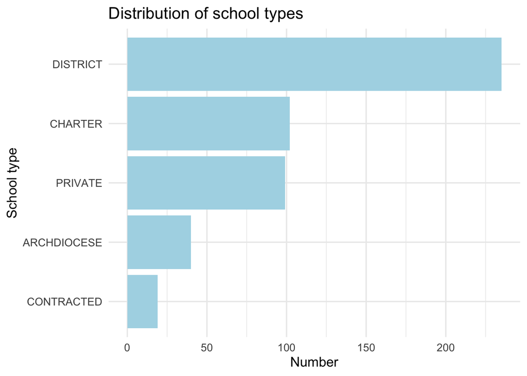

```r
bike_network <- st_read("Data/Bike_Network/Bike_Network.shp")
schools <- st_transform(schools, 2272)
crime <- st_transform(crime, 2272)
bike_network <- st_transform(bike_network, 2272)

library(dplyr)
library(ggplot2)

## school type
schools %>%
  st_drop_geometry() %>%
  count(type_speci, sort = TRUE) %>%
  ggplot(aes(x = reorder(type_speci, n), y = n)) +
  geom_bar(stat = "identity", fill = "lightblue") +
  coord_flip() +
  labs(
    title = "Distribution of school types",
    x = "School type",
    y = "Number"
  ) +
  theme_minimal(base_size = 13)
```

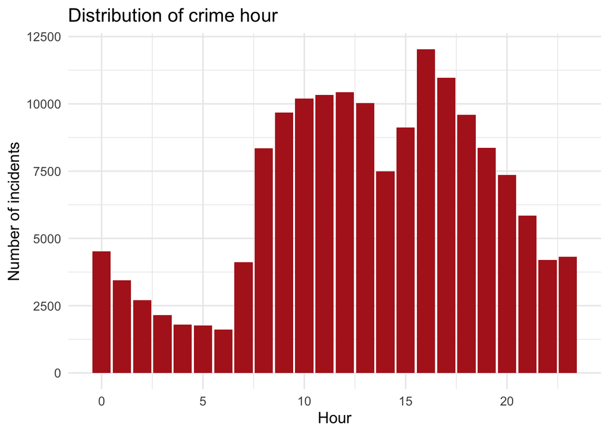

```r
# Crime Hour
crime %>%
  st_drop_geometry() %>%
  count(hour) %>%
  ggplot(aes(x = hour, y = n)) +
  geom_col(fill = "firebrick") +
  labs(
    title = "Distribution of crime hour",
    x = "Hour",
    y = "Number of incidents"
  ) +
  theme_minimal(base_size = 13)
```

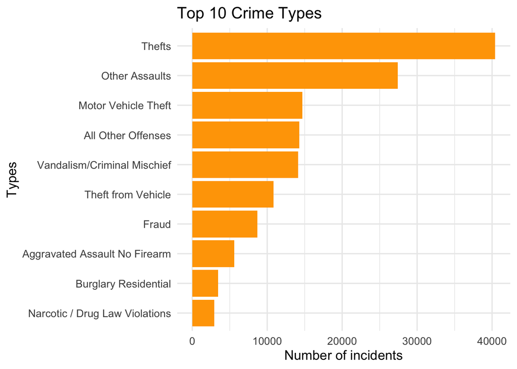

```r
#crime types
crime %>%
  st_drop_geometry() %>%
  count(text_gener, sort = TRUE) %>%
  slice_max(n, n = 10) %>%
  ggplot(aes(x = reorder(text_gener, n), y = n)) +
  geom_bar(stat = "identity", fill = "orange") +
  coord_flip() +
  labs(
    title = "Top 10 Crime Types",
    x = "Types",
    y = "Number of incidents"
  ) +
  theme_minimal(base_size = 13)
```

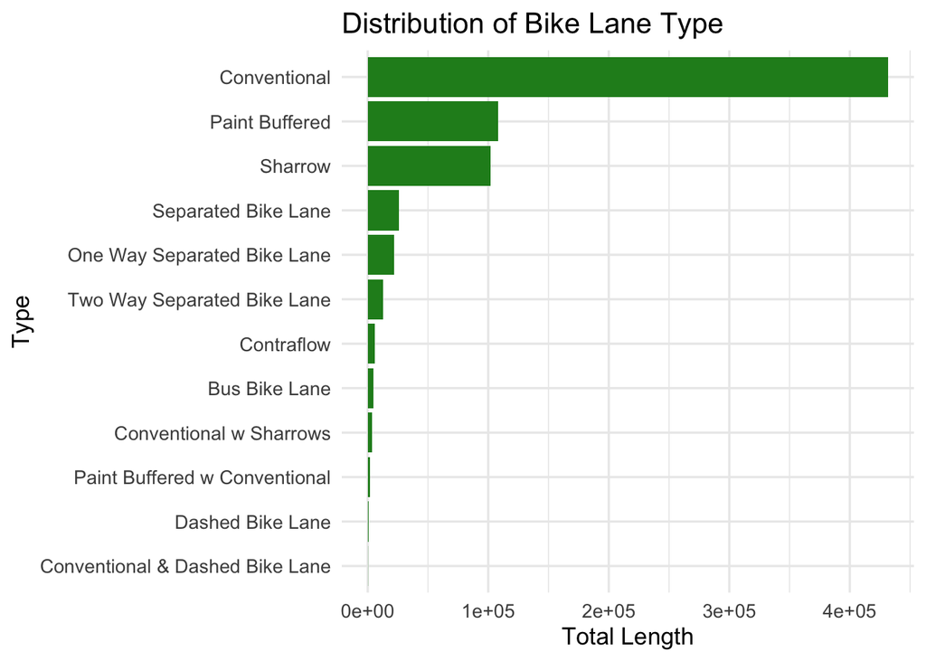

```r
# Bike lane
bike_length_summary <- bike_network %>%
  st_drop_geometry() %>%
  group_by(TYPE) %>%
  summarise(total_length = sum(Shape__Len, na.rm = TRUE)) %>%
  arrange(desc(total_length))

ggplot(bike_length_summary, aes(x = reorder(TYPE, total_length), y = total_length)) +
  geom_bar(stat = "identity", fill = "forestgreen") +
  coord_flip() +
  labs(
    title = "Distribution of Bike Lane Type",
    x = "Type",
    y = "Total Length"
  ) +
  theme_minimal(base_size = 13)
```

**Questions to answer:**

Write a clear research statement that your analysis will answer.

**Examples:**

- “Do vulnerable tracts have adequate public transit access to hospitals?”
- “Are EMS stations appropriately located near vulnerable populations?”
- “Do areas with low vehicle access have worse hospital access?”

My question is **“Are school zones safe for walking/biking, or are they crime hotspots?”**

3. **Conduct spatial analysis**

Use at least TWO spatial operations to answer your research question.

**Required operations (choose 2+):**

- Buffers
- Spatial joins
- Spatial filtering with predicates
- Distance calculations
- Intersections or unions
- Point-in-polygon aggregation

**Your Task:**

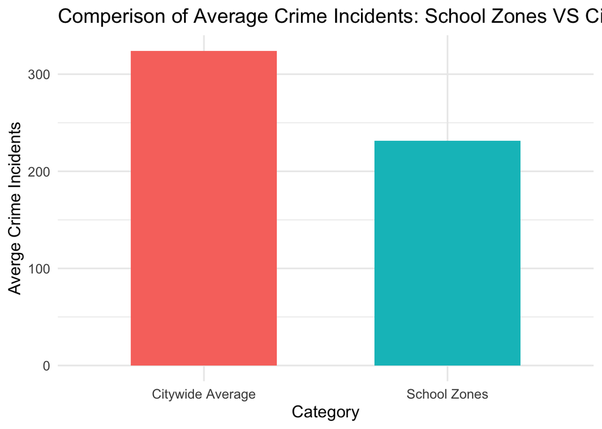

```r
# Your spatial analysis

# I have loaded data sets and make simple statistical analysis for each of them in the previous chunk

# Create buffer for schools

schools <- schools %>% mutate(school_id = row_number())
zones <- st_buffer(schools, dist = 1000)

# Calculate the crime number

crime_by_zone <- crime %>%
  st_join(zones %>% select(school_id), join = st_within) %>%
  st_drop_geometry() %>%
  count(school_id, name = "crime_count")


# Calculate the bike lane length
bike_in_zone <- st_intersection(bike_network, zones %>% select(school_id))

bike_len_by_zone <- bike_in_zone %>%
  mutate(len_ft = as.numeric(st_length(.))) %>%
  st_drop_geometry() %>%
  group_by(school_id) %>%
  summarise(bike_len_ft = sum(len_ft, na.rm = TRUE), .groups = "drop")

# Combine the result
zone_stats <- zones %>%
  left_join(crime_by_zone,    by = "school_id") %>%
  left_join(bike_len_by_zone, by = "school_id")

# Calculate average number of the crime incidents and bike lane length
zone_summary <- zone_stats %>%
  st_drop_geometry() %>%
  summarise(
    mean_crime = mean(crime_count, na.rm = TRUE),
    mean_bike_len = mean(bike_len_ft, na.rm = TRUE)
  )

city_summary <- tibble(
  mean_crime = nrow(crime) / nrow(zones),
  mean_bike_len = sum(st_length(bike_network)) / nrow(zones)
)

# Combine results
comparison <- rbind(
  data.frame(Category = "School Zones",
             mean_crime = zone_summary$mean_crime,
             mean_bike_len = zone_summary$mean_bike_len),
  data.frame(Category = "Citywide Average",
             mean_crime = city_summary$mean_crime,
             mean_bike_len = city_summary$mean_bike_len)
)

# Draw diagram
ggplot(comparison, aes(x = Category, y = mean_crime, fill = Category)) +
  geom_bar(stat = "identity", width = 0.6) +
  labs(
    title = "Comperison of Average Crime Incidents: School Zones VS City",
    y = "Averge Crime Incidents"
  ) +
  theme_minimal(base_size = 14) +
  theme(legend.position = "none")
```

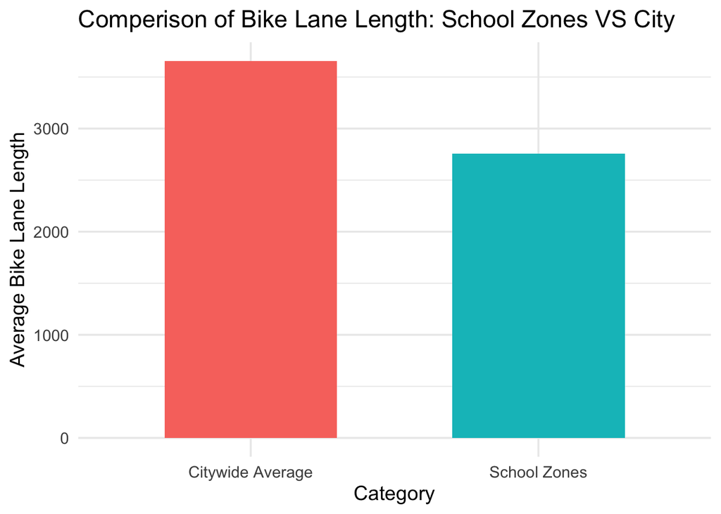

```r
ggplot(comparison, aes(x = Category, y = mean_bike_len, fill = Category)) +
  geom_bar(stat = "identity", width = 0.6) +
  labs(
    title = "Comperison of Bike Lane Length: School Zones VS City",
    y = "Average Bike Lane Length"
  ) +
  theme_minimal(base_size = 14) +
  theme(legend.position = "none")
```

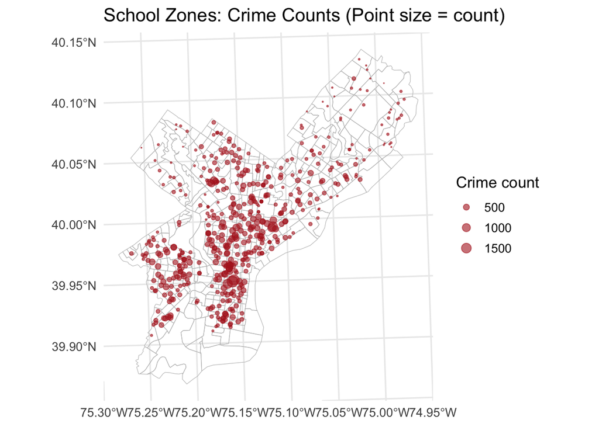

```r
# Mapping

# Get tracts of Philly
tracts_phl <- get_acs(
  geography = "tract",
  state     = "PA",
  county    = "Philadelphia",
  variables = "B01003_001",
  survey    = "acs5",
  year      = 2022,
  geometry  = TRUE,
  cache_table = TRUE
) %>%
  select(GEOID, NAME, pop = estimate, geometry) %>%
  st_transform(2272)

# point_on_surface
zone_points <- zone_stats |>
  mutate(geometry = st_point_on_surface(geometry),
         bike_len_mile = bike_len_ft / 5280) |>
  st_as_sf()

# Crime point map
ggplot() +
  geom_sf(data = tracts_phl, fill = NA, color = "grey", linewidth = 0.2) +
  geom_sf(data = zone_points, aes(size = crime_count), color = "firebrick", alpha = 0.6) +
  scale_size_continuous(name = "Crime count", range = c(0, 4)) +
  labs(title = "School Zones: Crime Counts (Point size = count)", x = NULL, y = NULL) +
  theme_minimal(base_size = 13) +
  theme(legend.position = "right")
```

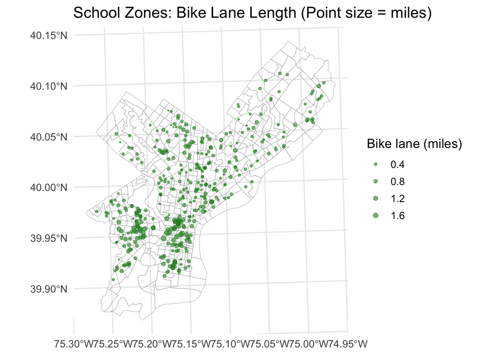

```r
# Bike lane point map
ggplot() +
  geom_sf(data = tracts_phl, fill = NA, color = "grey", linewidth = 0.2) +
  geom_sf(data = zone_points, aes(size = bike_len_mile), color = "forestgreen", alpha = 0.6) +
  scale_size_continuous(name = "Bike lane (miles)", range = c(0.1, 2)) +
  labs(title = "School Zones: Bike Lane Length (Point size = miles)", x = NULL, y = NULL) +
  theme_minimal(base_size = 13) +
  theme(legend.position = "right")
```

**Analysis requirements:**

- Clear code comments explaining each step
- Appropriate CRS transformations
- Summary statistics or counts
- At least one map showing your findings
- Brief interpretation of results (3-5 sentences)

**Your interpretation:**

School zones have fewer crime incidents and bike lane length compared to city average. More pedestrian-friendly projects should be applied to school areas. For the spatial difference, higher concentrations of crimes are observed around schools in central and southern Philadelphia. School zones with longer bike lane coverage are mostly located in the city’s core and western areas. Planning efforts should focus on improving safety in school zones with higher crime risks, especially in central and southern Philadelphia. Expanding connected and protected bike lanes around schools can promote safer and more accessible environments for students.

## Finally - A few comments about your incorporation of feedback!

Take a few moments to clean up your markdown document and then write a line or two or three about how you may have incorporated feedback that you recieved after your first assignment.

I need to hide my API Key and printed tables!

## Submission Requirements

**What to submit:**

1. **Rendered HTML document posted to your course portfolio** with all code, outputs, maps, and text
   - Use `embed-resources: true` in YAML so it’s a single file
   - All code should run without errors
   - All maps and charts should display correctly

**File naming:** `LastName_FirstName_Assignment2.html` and `LastName_FirstName_Assignment2.qmd`